# Spain: Agenda initiative (Pre-Test case)

# 1 Country Overview

> Apart from relevant context information, we ought to have a table such as the one in the example (here we use the ECI to illustrate the type of information needed)

**CLICK TO SEE RESULTS**

| Variable | Source | Year | Entry | Description |
| --- | --- | --- | --- | --- |
| Constitutional provision | Art 11(4) TEU) | N/A | 2009 | In 2009 The Lisbon Treaty (introducing the European citizens’ initiative) enters into force. |
| Implementing law | Regulation (EU) 2011/211 | 2011 | 2012 | The implementing law enter into force and the ECI can be used |
| Reform law 1 | Regulation (EU) 2019/788 | 2019 | 2020 | New rules on the European citizens’ initiative enter into force |

# 2 Synoptic overview

## 2.1 Table: Overview of instrument features

**CLICK TO SEE RESULTS**

| # | Type | Question | Answer | Sources | Comment |
| --- | --- | --- | --- | --- | --- |
| 1 | Legal basis | What is the legal basis for this instrument |  | Article 87.3 of the Spanish Constitution and Organic Law 3/1984, March 26 |  |
| 2 | Signatures | What is the total number of signatures required? | 1.36 | Article 87.3 of the Spanish Constitution and Organic Law 3/1984, March 26 | 500000 |
| 3 | Signatures | What is the time limit for collecting the required number of signatures (in days)? | 365 | Article 7 of the Organic Law 3/1984 | The time limit is 9 months, but it can be extended for an additional 3 months. |
| 4 | Signatures | Is it possible to gather signatures electronically? | Yes | Article 7.4 of the Organic Law 3/1984 | NA |
| 5 | Formal limits | Does the proposal have to be submitted as a (draft) legal text? | Yes | Article 3.2 a) of the Organic Law 3/1984 | NA |
| 6 | Formal limits | Are there any formal limits on the wording of the agenda initiative? | No | NA | The only formal requirement is a reasoning for the proposal, but this is separate from the wording: The submission must contain: a) The articulated text of the proposed Law preceded by a statement of … |
| 7 | Formal limits | Is there a clarity of the question requirement? | NA | NA | NA |
| 8 | Formal limits | Is there a unity of form requirement? | NA | NA | NA |
| 9 | Formal limits | Is there a unity of substance requirement? | NA | NA | NA |
| 10 | Formal limits | Are there any other formal limits? If Yes, describe in comments. | NA | NA | NA |
| 11 | Formal limits | List of formal limits | NA | NA | NA |
| 12 | Formal check | Is there a formal admissibility check? | Yes | Articles 3, 4 and 5 of the Organic Law 3/1984 | NA |
| 13 | Formal check | Who decides about the formal admissibility? | Parliament | Articles 9 and 10 of the Organic Law 3/1984 | NA |
| 14 | Formal check | Is there a legal remedy against the decision on formal admissibility? | Yes | Article 6 of the Organic Law 3/1984 | NA |
| 15 | Formal check | Who decides about the claim for remedy in the formal admissibility procedure? | Constitutional court | Article 6 of the Organic Law 3/1984 | NA |
| 16 | Formal check | Does the formal admissibility procedure take place before the signature collection? | Yes | Articles 4, 5 and 7 of the Organic Law 3/1984 | NA |
| 17 | Formal check | Do participants have a right to be heard in the formal admissibility procedure? | No | Articles 126 and 127 of the Spanish Congress of Deputies’ Standing Orders | NA |
| 18 | Substantive limits | Are agenda initiative on constitutional amendments prohibited? | Yes | Articles 166, 87 of the Spanish Constitution | NA |
| 19 | Substantive limits | Can only issues of special importance be the subject of agenda initiative? | No | Articles 1, 2 and 3 of the Organic Law 3/1984 | NA |
| 20 | Substantive limits | Can only certain enumerated issues be the subject of agenda initiative? | No | Articles 1, 2 and 3 of the Organic Law 3/1984 | NA |
| 21 | Substantive limits | Are there any prohibited issues? | Yes | Article 2 of the Organic Law 3/1984 | The following matters are excluded from the popular legislative initiative: those that are typical of Organic Laws; those of a tax nature; those of international character; those referring to the prer… |
| 22 | Substantive limits | List of LIDD prohibitions | International law; Fundamental rights/freedoms; State form; State symbols; Language; Territorial issues; Finances; National security; Emergency powers; Pardons/Amnesty; Election/Referendum rules; Legi… | NA | NA |
| 23 | Substantive limits | Are there any other prohibited issues? | No | NA | NA |
| 24 | Substantive check | Is there a substantive admissibility check? | Yes | Article 2 of the Organic Law 3/1984 | NA |
| 25 | Substantive check | Who decides about the substantive admissibility? | Parliament | Articles 4 and 5 of the Organic Law 3/1984 | NA |
| 26 | Substantive check | Is there a legal remedy against the decision on substantive admissibility? | Yes | Article 6 of the Organic Law 3/1984 | NA |
| 27 | Substantive check | Who decides about the claim for remedy in the substantive admissibility procedure? | Constitutional court | Articles 6 of the Organic Law 3/1984 | NA |
| 28 | Substantive check | Does the substantive admissibility procedure take place before the signature collection? | Yes | Articles 4 and 5 of the Organic Law 3/1984 | NA |
| 29 | Substantive check | Do participants have a right to be heard in the substantive admissibility procedure? | No | Articles 126 and 127 of the Spanish Congress of Deputies’ Standing Orders | NA |

# 3 Descriptive statistics

There have been a total of 118 AI’s between 1990 and 2020.

## 3.1 Figure: Distribution of initiatives (per year)

**CLICK TO SEE RESULTS**

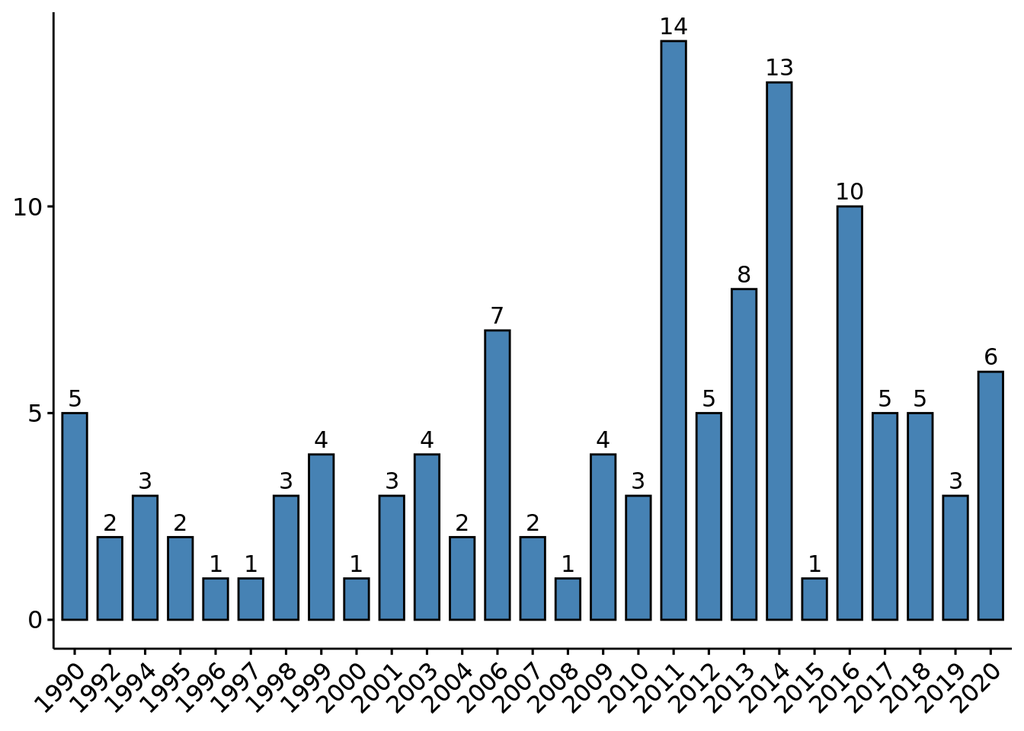

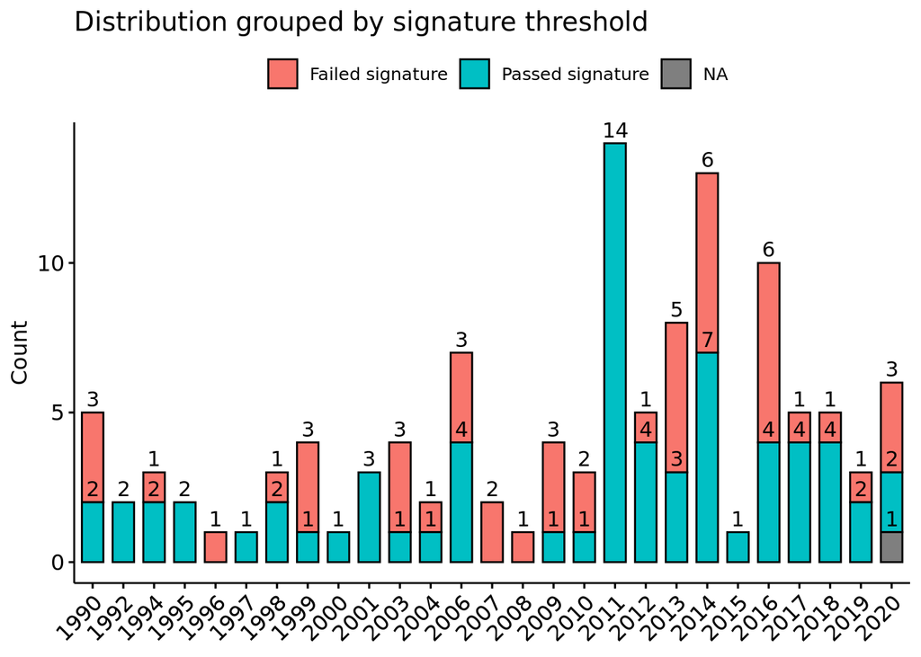

## 3.2 Table: Distribution of topics

**CLICK TO SEE RESULTS**

All initiatives (both Passed & Failed the signature thresholds)

| Topic | n | Percent |
| --- | --- | --- |
| Interior Policies | 52 | 44.1 |
| Labour & Social | 32 | 27.1 |
| Economy | 11 | 9.3 |
| Political / Electoral System | 7 | 5.9 |
| Health | 5 | 4.2 |
| Moral & Ethics | 5 | 4.2 |
| Environment | 3 | 2.5 |
| Education | 2 | 1.7 |
| Constitution | 1 | 0.8 |

Only initiatives that Passed the signature threshold

| Topic | n | Percent |
| --- | --- | --- |
| Interior Policies | 27 | 39.1 |
| Labour & Social | 18 | 26.1 |
| Economy | 6 | 8.7 |
| Political / Electoral System | 6 | 8.7 |
| Health | 4 | 5.8 |
| Moral & Ethics | 4 | 5.8 |
| Education | 2 | 2.9 |
| Constitution | 1 | 1.4 |
| Environment | 1 | 1.4 |

Comparing Topics based on Signature Threshold

| Topic | Failed signature | Passed signature |
| --- | --- | --- |
| Constitution | NA | 1 |
| Economy | 5 | 6 |
| Education | NA | 2 |
| Environment | 1 | 1 |
| Health | 1 | 4 |
| Interior Policies | 25 | 27 |
| Labour & Social | 14 | 18 |
| Moral & Ethics | 1 | 4 |
| Political / Electoral System | 1 | 6 |

## 3.3 Table: Signature threshold

**CLICK TO SEE RESULTS**

| Signature threshold | n | Percent |
| --- | --- | --- |
| Passed signature | 69 | 59 |
| Failed signature | 48 | 41 |

## 3.4 Table: Admissibility (failed + passed signature threshold)

**CLICK TO SEE RESULTS**

| Admissible | n | Percent |
| --- | --- | --- |
| Admissible | 71 | 62.3 |
| Inadmissible | 43 | 37.7 |

## 3.5 Table: Admissibility (passed signature threshold)

**CLICK TO SEE RESULTS**

| Admissible | n | Percent |
| --- | --- | --- |
| Admissible | 23 | 34.8 |
| Inadmissible | 43 | 65.2 |

# 4 QCA-like Case Summary

> **N.B.** This data in the table is completely fictitious. After the case has been analysed properly, it will be possible to construct a simplified model with the most important variables -probably with many more variables, which will have more varied values.

**CLICK TO SEE RESULTS**

| Variable | Value |
| --- | --- |
| Timing | PreTest |
| Institutional independence | Low |
| Practice | Medium |
| Formal limits | Low |
| Substantive limits | High |
| Rejection Rate | High |

# 5 Annex: Data collection process

# 6 Annex: References and links